# Forecasting CO2 emissions using ARIMA models in Brazil, China, EU, India and US

### Individual Time series plots

To have a more detailed view of each countries dioxide emissions we plot each time series plot individually.

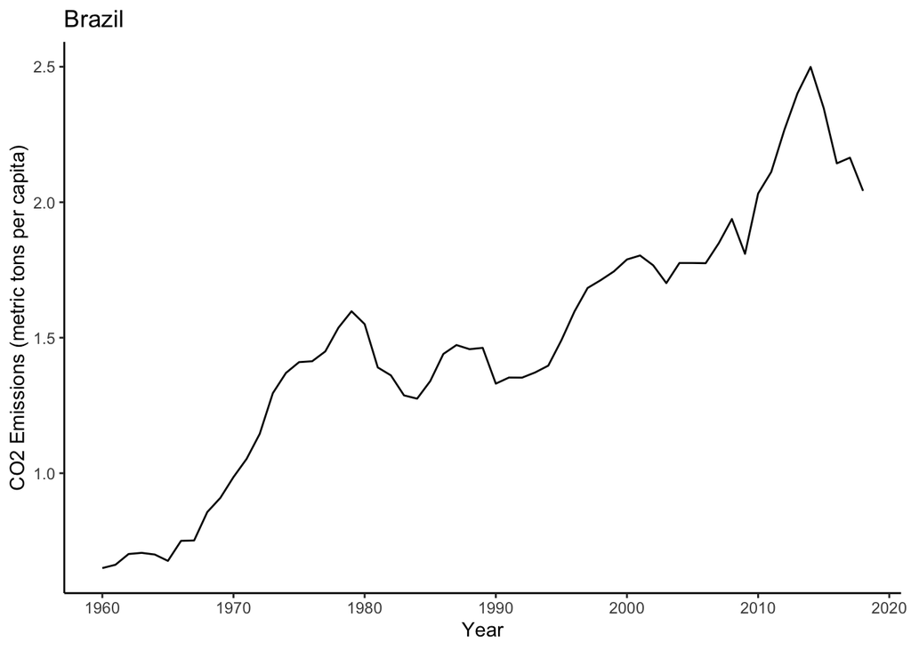

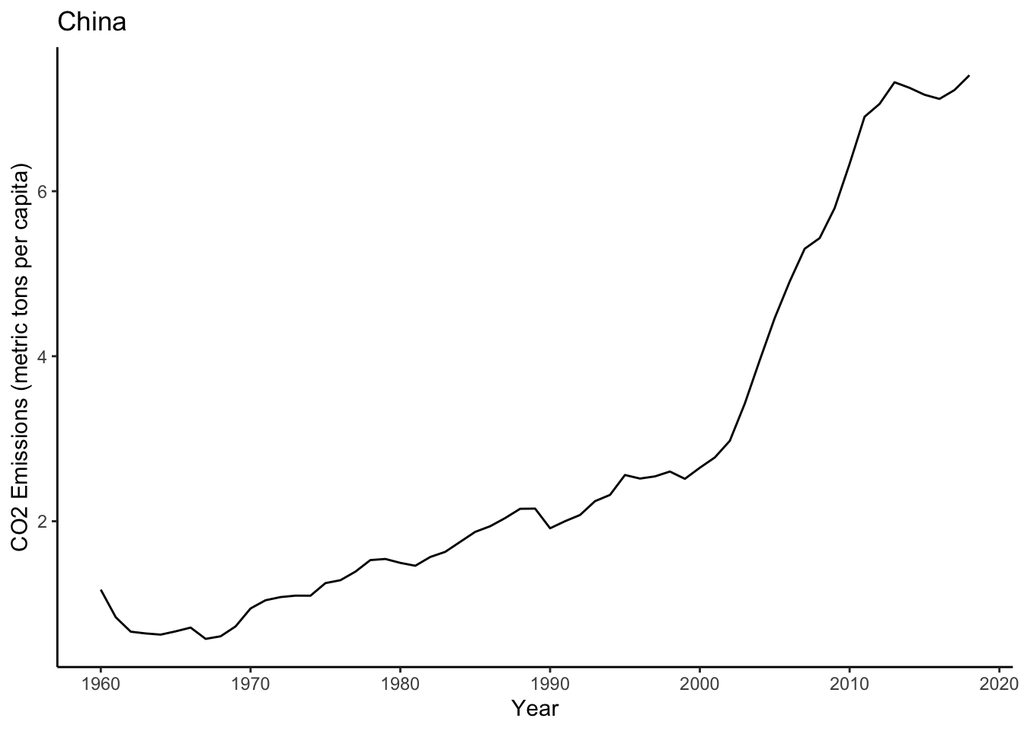

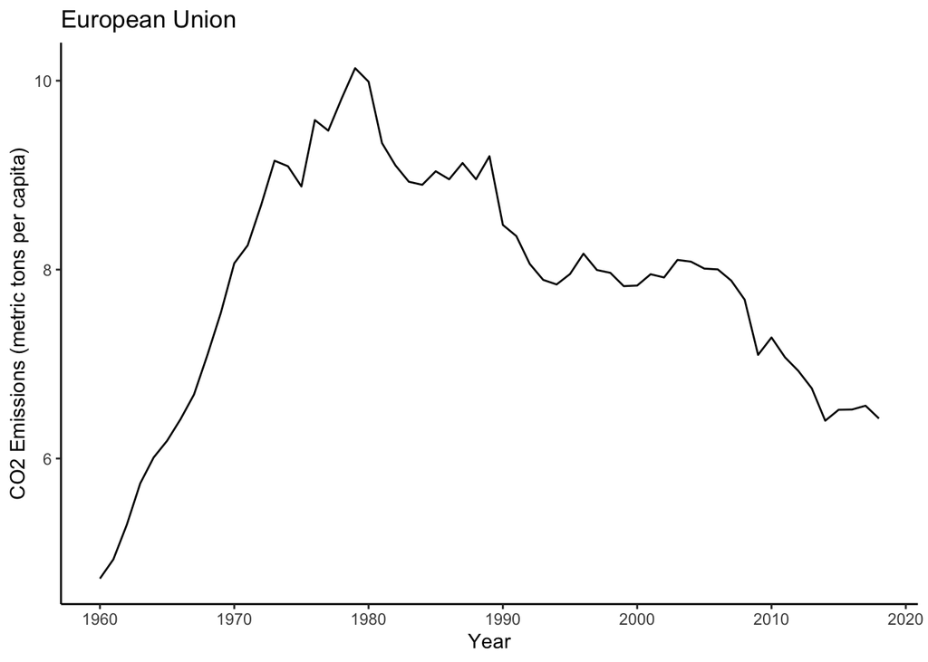

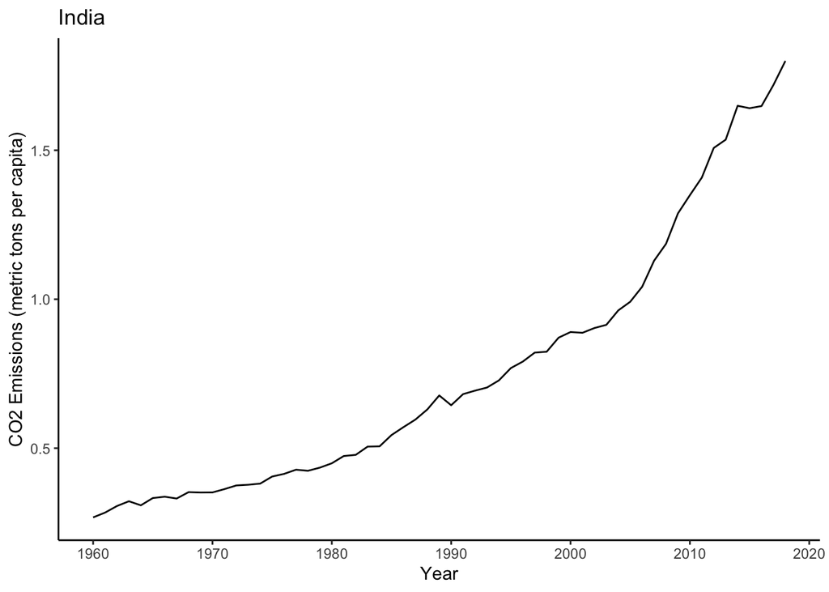

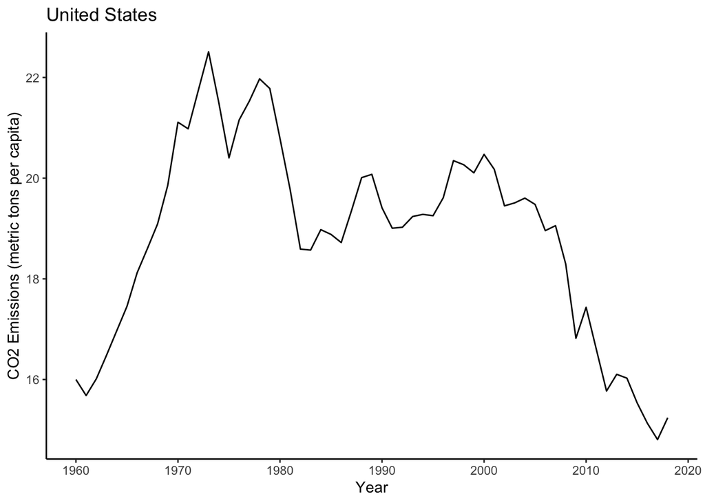

### Autocorrelation plots and Partial Autocorrelation plots

Using the autocorrelation function formula:
$$\rho_k =
\frac{\gamma_k}{\gamma_o}=\frac{Cov[y_t,y_{t-k}]}{Var(y_t)}$$
all ACF are calculated for each country group. This works as a visual way to determine if a time series object is stationary or not. In the next section we run the necessary test to confirm our findings from the ACFS.

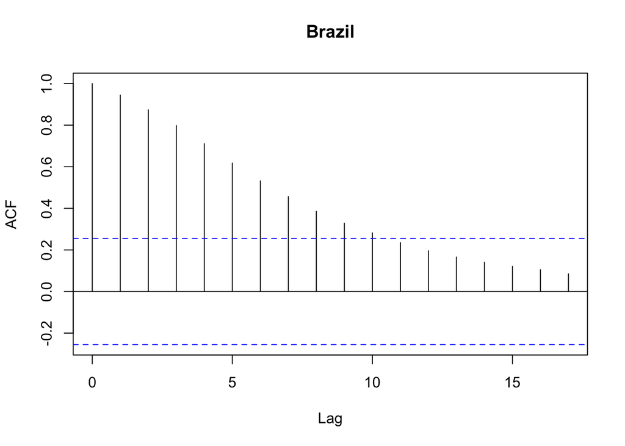

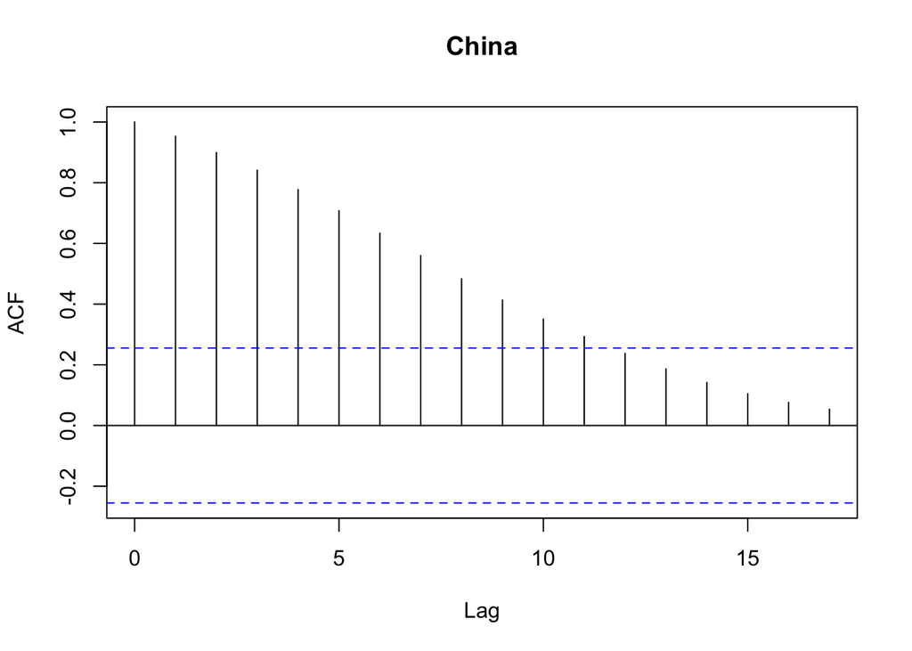

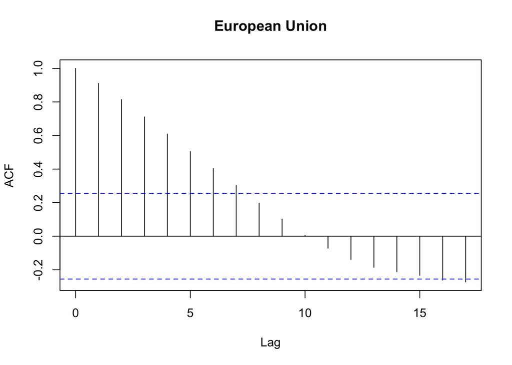

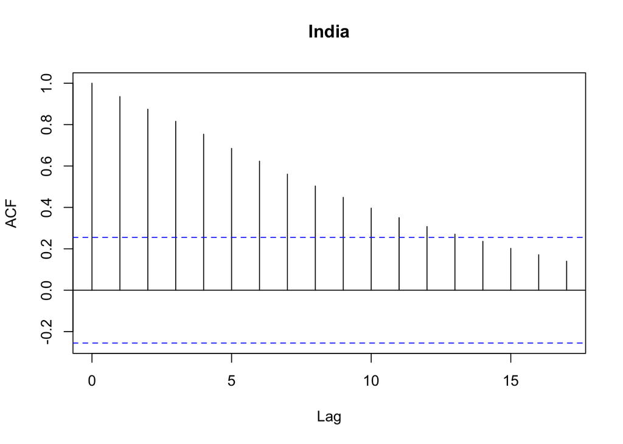

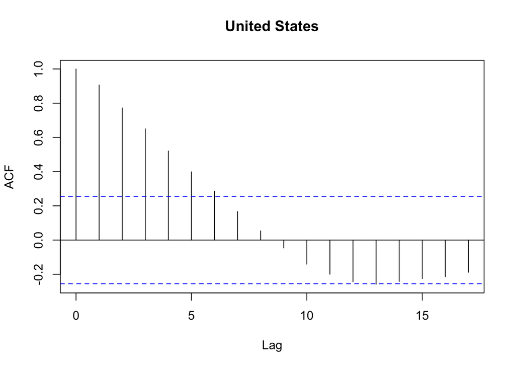

To further assist with our model choice, we use the Partial Autocorrelation Functions plots as well.

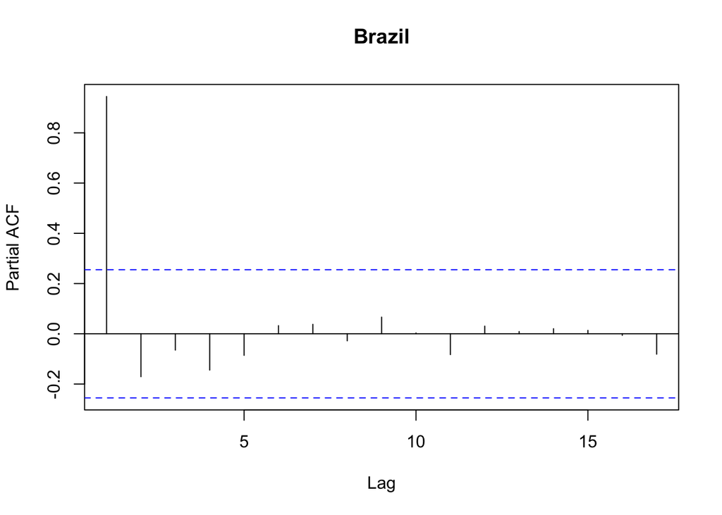

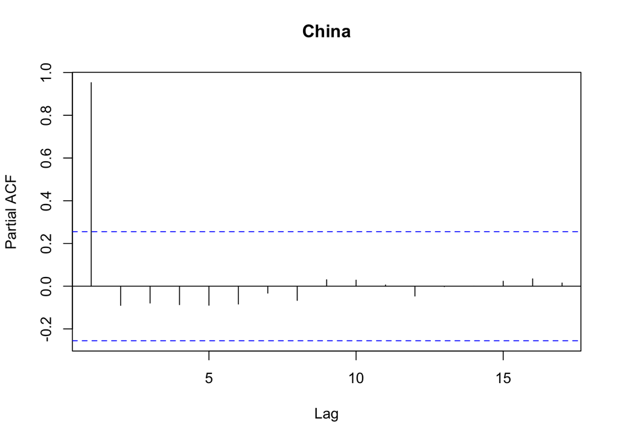

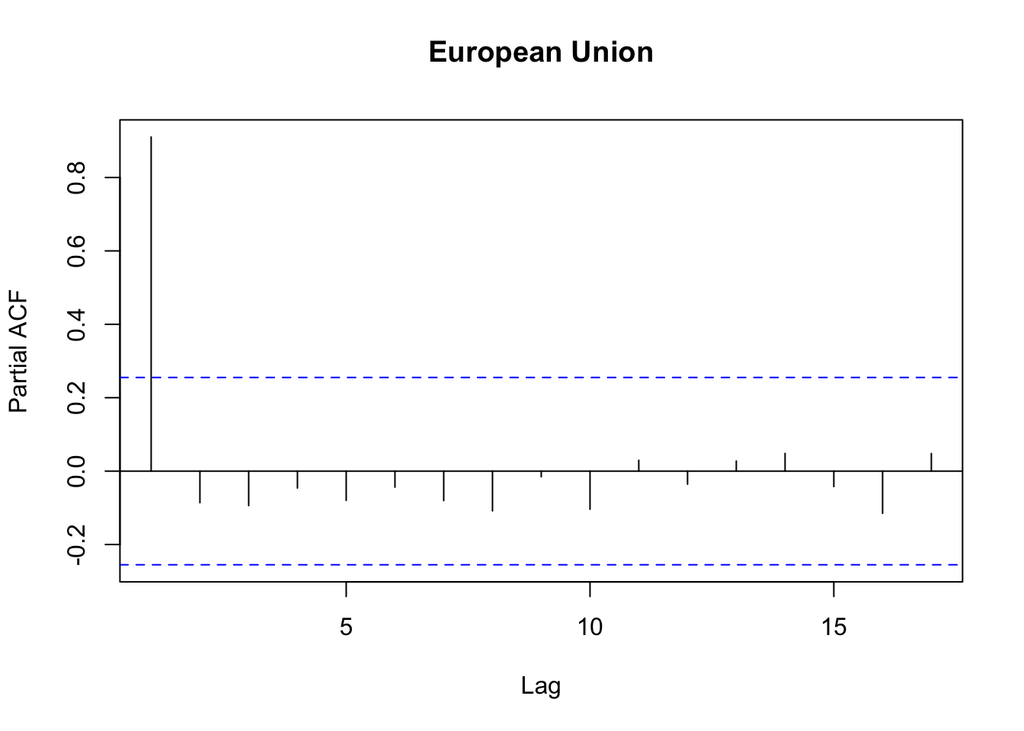

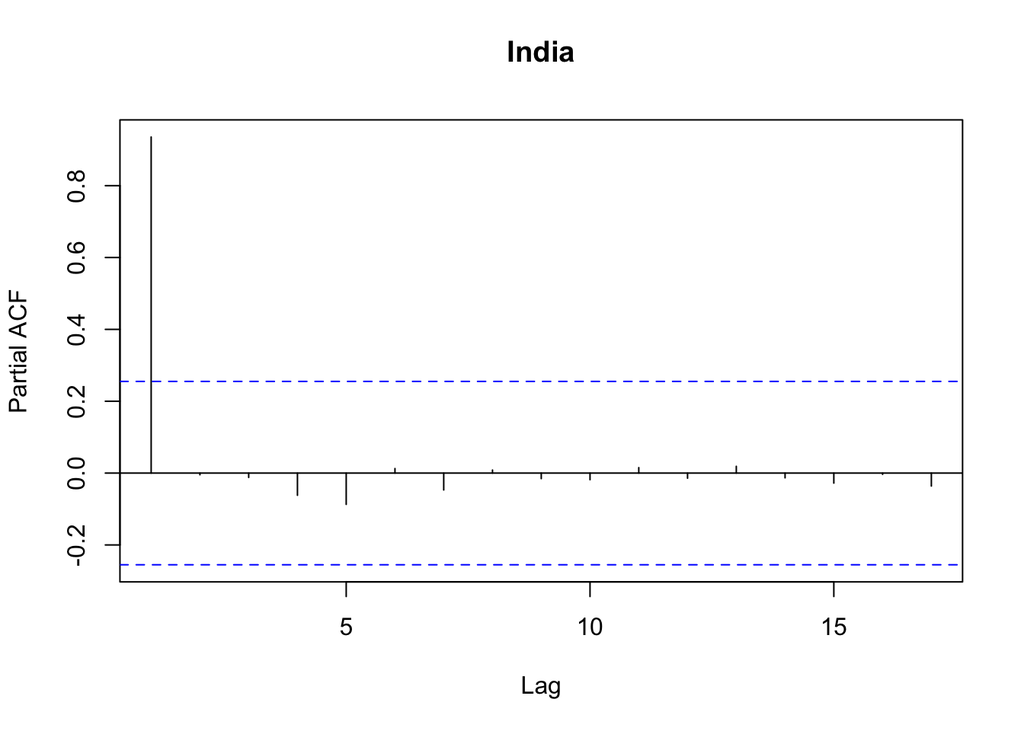